# Low plant density enhances gene dispersal in the Amazonian understory herb Heliconia acuminata - Côrtes - 2013 - Molecular Ecology - Wiley Online Library

[Molecular Ecology](https://onlinelibrary.wiley.com/journal/1365294x)

[Volume 22, Issue 22](https://onlinelibrary.wiley.com/toc/1365294x/2013/22/22) p. 5716-5729

[figure not shown]

Original Article

Full Access

# Low plant density enhances gene dispersal in the Amazonian understory herb *Heliconia acuminata*

[Marina C. Côrtes](https://onlinelibrary.wiley.com/action/doSearch?ContribAuthorRaw=C%C3%B4rtes%2C+Marina+C),

Correspondence: Marina C. Côrtes, Fax: (212) 854 8188; E-mail:

[María Uriarte](https://onlinelibrary.wiley.com/action/doSearch?ContribAuthorRaw=Uriarte%2C+Mar%C3%ADa),

[Maristerra R. Lemes](https://onlinelibrary.wiley.com/action/doSearch?ContribAuthorRaw=Lemes%2C+Maristerra+R),

[Rogério Gribel](https://onlinelibrary.wiley.com/action/doSearch?ContribAuthorRaw=Gribel%2C+Rog%C3%A9rio),

[W. John Kress](https://onlinelibrary.wiley.com/action/doSearch?ContribAuthorRaw=John+Kress%2C+W),

[Peter E. Smouse](https://onlinelibrary.wiley.com/action/doSearch?ContribAuthorRaw=Smouse%2C+Peter+E),

[Emilio M. Bruna](https://onlinelibrary.wiley.com/action/doSearch?ContribAuthorRaw=Bruna%2C+Emilio+M),

First published: 20 August 2013

https://doi.org/10.1111/mec.12495

Citations: 16

## Abstract

In theory, conservation genetics predicts that forest fragmentation will reduce gene dispersal, but in practice, genetic and ecological processes are also dependent on other population characteristics. We used Bayesian genetic analyses to characterize parentage and propagule dispersal in *Heliconia acuminata* L. C. Richard (Heliconiaceae), a common Amazonian understory plant that is pollinated and dispersed by birds. We studied these processes in two continuous forest sites and three 1-ha fragments in Brazil's Biological Dynamics of Forest Fragments Project. These sites showed variation in the density of *H. acuminata*. Ten microsatellite markers were used to genotype flowering adults and seedling recruits and to quantify realized pollen and seed dispersal distances, immigration of propagules from outside populations, and reproductive dominance among parents. We tested whether gene dispersal is more dependent on fragmentation or density of reproductive plants. Low plant densities were associated with elevated immigration rates and greater propagule dispersal distances. Reproductive dominance among inside-plot parents was higher for low-density than for high-density populations. Elevated local flower and fruit availability is probably leading to spatially more proximal bird foraging and propagule dispersal in areas with high density of reproductive plants. Nevertheless, genetic diversity, inbreeding coefficients and fine-scale spatial genetic structure were similar across populations, despite differences in gene dispersal. This result may indicate that the opposing processes of longer dispersal events in low-density populations vs. higher diversity of contributing parents in high-density populations balance the resulting genetic outcomes and prevent genetic erosion in small populations and fragments.

## Introduction

Tropical deforestation and habitat fragmentation are proceeding at unprecedented rates (FAO 2011), with ecological and genetic consequences for plant populations (Laurance *et al*. 2002; Aguilar *et al*. 2008; DiBattista 2008). Forest fragmentation is thought to disrupt gene flow by reducing dispersal distances and immigration of propagules among populations (Young *et al*. 1996; Ouborg *et al*. 2006), enhancing fine-scale spatial genetic structure and reducing effective population sizes within populations (Young *et al*. 1996; Wang *et al*. 2011). Low effective population sizes can change plant-mating patterns, increasing genetic drift and inbreeding (Aguilar *et al*. 2008; Eckert *et al*. 2010). Effective population size is reduced by high reproductive dominance among adults, increasing the level of correlated parentage (Robledo-Arnuncio *et al*. 2004; Breed *et al*. 2012a) and source-biased limitation (Jordano & Godoy 2002; García & Grivet 2011), resulting in fewer individuals successfully contributing genes to the next generation (Young & Pickup 2010; Moran & Clark 2012b).

Over the long term, these processes are predicted to decrease population genetic diversity within a given population and increase genetic divergence among isolated patches (Aguilar *et al*. 2008; DiBattista 2008; Vranckx *et al*. 2012). Empirical studies, however, have often found extensive gene flow via pollen (White *et al*. 2002; Dick *et al*. 2003; Lander *et al*. 2010) or seed (Bacles *et al*. 2006; Kamm *et al*. 2009) in forest fragments. Such conflicting evidence, known as the ‘paradox of forest fragmentation genetics’ (Kramer *et al*. 2008), is hardly surprising, given that neither the plants themselves nor their animal propagule vectors exhibit uniform responses to habitat fragmentation (Hobbs & Yates 2003; Watling & Donnelly 2006).

Including the ecological characteristics of plant and animal populations in studies of fragmentation genetics should help to elucidate the mechanisms that determine propagule flow. Although the variation in plant abundance across fragmented populations is regarded as an important factor impacting levels of inbreeding and gene flow, it has seldom been explicitly related to the genetic consequences of disturbance (Honnay & Jacquemyn 2007). Low population density can affect mating and pollen dispersal, by limiting pollinator and seed dispersal visitation and increasing inbreeding rates (Ghazoul 2005; Eckert *et al*. 2010). Conversely, pollen dispersal distances may increase in low-density populations, by virtue of high mobility of pollinators in search of food sources (Byrne *et al*. 2007; Llorens *et al*. 2012).

Plant population-level characteristics that influence pollen and seed dispersal, such as adult density or flower and seed production, are often affected by landscape modification (Kolb 2008; Eckert *et al*. 2010; Herrera *et al*. 2011). In that context, an increasing number of studies have conducted paternity or maternity analysis, while taking into consideration the effects of changing plant and animal abundance or behaviour across sites (Dick *et al*. 2003; Byrne *et al*. 2007; García *et al*. 2009; Lander *et al*. 2010). Yet, studies of animal-vectored propagule flow across fragmented landscapes are still uncommon (but see Kamm *et al*. 2009).

The direct assessment of pollen and seed dispersal permits more realistic inference about the evolutionary consequences of fragmentation for natural plant populations (Sork & Smouse 2006; Bacles & Jump 2011) and provides insights into processes that drive contemporary gene flow, rather than relying on indirect comparisons of extant genetic variation, as a means of assessing historical patterns of gene flow (Oddou-Muratorio & Klein 2008; Meagher 2010). Highly polymorphic molecular markers (e.g. microsatellites), coupled with parentage analyses, can provide an accurate assessment of contemporary gene flow (Ashley 2010). Researchers using highly polymorphic markers for parentage analysis can employ exclusion methods, in which candidate adult plants that do not share alleles with the offspring are eliminated as parental candidates for that particular seedling. Alternatively, they assign the most likely single or pair of parents, based on log-likelihood ratios (Jones & Ardren 2003; Jones *et al*. 2010). These classic approaches, however, can provide poor results if polymorphism is insufficient or if the presence of null alleles or genotype mistyping errors are not taken into account (Chybicki & Burczyk 2010; Jones *et al*. 2010). Moreover, researchers are often less interested in the parentage allocation per se than in population-level processes such as seed and pollen dispersal distances (Oddou-Muratorio & Klein 2008; Moran & Clark 2011, 2012a). In contrast, full probability models can jointly estimate population-level parameters and parentage, while incorporating both genetic and ecological data, such as spatial location and reproductive status of individual plants (Burczyk *et al*. 2006; Hadfield *et al*. 2006; Moran & Clark 2011).

Here, we use a hierarchical Bayesian approach to quantify the contributions of pollen and seed movement to gene dispersal in *Heliconia acuminata* L. C. Richard (Heliconiaceae), an understory herb pollinated by hummingbirds (Bruna *et al*. 2004), whose seed is dispersed by manakins and thrushes (Uriarte *et al*. 2011). The species is native to central Amazonia and the Guyanas and has been the subject of a long-term demographic study in an experimentally fragmented landscape (Gascon & Bierregaard 2001; Bruna & Kress 2002). Using this model system, we ask whether fragmentation and population density influence: (i) realized pollen and seed dispersal distances; (ii) immigration of propagules from outside populations; and (iii) reproductive dominance among parents.

We tested two contrasting hypotheses. First, assuming the traditional prediction that forest fragmentation interrupts movement of animals and plant propagules, we hypothesized that forest fragments would experience less gene dispersal than continuous forest sites. Alternatively, if animal movement is driven by the availability of food resources and if dispersers are able to move freely across the landscape, we hypothesized that the local density of reproductive plants would exert a greater influence on gene dispersal. To better understand the resulting patterns of gene dispersal, we also characterized the genetic diversity, inbreeding and fine-scale spatial genetic structure of seedlings and reproductive plants. We expected that reduced gene dispersal, low immigration rates and high reproductive dominance would increase spatial aggregation and mating of related plants. Ultimately, these patterns should result in stronger fine-scale spatial genetic structure, higher inbreeding coefficients and decreased genetic diversity.

## Materials and methods

### Study site and system

The study was conducted at the Biological Dynamics of Forest Fragments Project (BDFFP), located 70 km north of Manaus, Brazil (2<sup>o</sup> 30′ S, 60′ W, Data S1, Supporting information). The BDFFP is a 1000 km<sup>2</sup> landscape comprised of forest fragment reserves, ranging in size from 1 to 100 ha and continuous forest sites. The fragments, experimentally created for scientific studies, were isolated from 1980 to 1984 by clear-cutting the trees surrounding the patches and, in some cases, burning the felled trees (Gascon & Bierregaard 2001). Subsequently, secondary forests have colonized and developed in the intervening clear-cuts (Mesquita *et al*. 2001). Studies comparing bird capture rates before and after the isolation of the BDFFP's fragments suggest that spatial structure of the landscape is likely to affect the abundance and movement of birds, including pollinators and seed dispersers of *Heliconia*, and that these effects can be expected to vary spatially and temporally (Stouffer & Bierregaard 1995a,b, 1996).

*Heliconia acuminata* has been the subject of a comprehensive demographic study since 1998 (Bruna & Kress 2002; Bruna 2003). Thirteen 0.5-ha plots (50 × 100 m) were established in continuous forest (*N* = 6 sites) and fragments (*N* = 7 fragments); all *H. acuminata* individuals in these plots were tagged, mapped and censused annually. In the present study, we used two plots in continuous forest and three in 1-ha fragments. The approximate distance between fragment edges to the nearest forest patch is 100 m (Data S1, Supporting information).

*Heliconia acuminata* has a scattered distribution in the forest understory (Bruna & Ribeiro 2005) and exhibits limited vegetative spread (E.M. Bruna and W.J. Kress, unpublished data). It is one of the most abundant understory plants at this site (E. Bruna & W.J. Kress, personal observation), although its local density can range from approximately 200–1600 plants/hectare (Bruna 2003). Plants produce 20–25 flowers per inflorescence, with individual flowers opening on successive days and for 1 day each. This reduces the probability of intra-inflorescence pollen transport by the pollinating hummingbirds (Dobkin 1984, 1987).

*Heliconia acuminata* is monoecious and functionally self-incompatible—in experiments designed to asses self-compatibility, autogamy was observed only in a small proportion of flowers in which self-pollen was manually placed on stigmas (16%). In contrast, in treatments where inflorescences were bagged and flowers were not manipulated, no fruits were produced (E. M. Bruna, unpublished data). The primary pollinators of *H. acuminata* are the hermit hummingbirds *Phaethornis superciliosus* and *Phaethornis bourcieri*, which ‘trapline’ from one inflorescence to the next, rather than establishing and defending a territory. They persist in both primary and secondary forests (Stouffer & Bierregaard 1995a). Evidence suggests that they may forage over large distances and move through a variety of habitats (Stouffer & Bierregaard 1995a), although no detailed information about their movement patterns is available. Visitation rates by pollinators are low (median = 0.182 visits/hour per plant), with hummingbirds failing to visit 28% of the observed plants (Bruna *et al*. 2004). These low visitation rates, coupled with the results of hand-pollination studies, suggest fruits resulting from self-pollination are extremely unlikely.

The primary dispersers of the seeds at this site are the white-collar thrush (*Turdus albicollis*), the thrush-like manakin (*Schiffornis turdinus*) and several species of manakins (*Pipra erythrocephala*, *Pipra pipra*, *Lepidothrix serena*, *Corapipo gutturalis*). Manakins disperse seeds an average of 19 m from maternal plants at this site, while thrushes have an average dispersal distance of 24 m (Uriarte *et al*. 2011). About 90% of ripe fruits were removed and that rate did not vary across the landscape nor was it affected by forest fragmentation or neighbourhood density of reproductive plants (Uriarte *et al*. 2011).

For parentage analysis, we collected samples of leaves from mapped seedlings instead of seeds, because we were interested in the realized pollen and seed dispersal, which is the ultimate result of both successful mating and seed deposition (Meagher & Thompson 1987). Here, we define gene dispersal as the combined movement of pollen and seeds that successfully transitions to seedlings and therefore changes the spatial distribution of genes in the population of interest. In 1999, we collected leaf samples of all reproductive plants (potential parents) and all seedlings in the five 0.5-ha plots. In 2009, we resampled the same plots, collecting leaf tissues of new seedlings that had recruited since 2000 and new reproductive plants that had flowered since 2000. Seedlings ranged in age from a few months (if recruited in 1999 or 2009) to about 9 years (if recruited in 2000). In 2009, we also recollected 123 surviving plants that had been genotyped from the 1999 collections to confirm that genotyping was consistent, independent of sample age, storage and DNA isolation methods. To increase the likelihood of determining the potential parents of seedlings inside the 0.5-ha plot, we also mapped and collected leaf tissue from all adults with inflorescences of current or past reproduction in a 20-m buffer around each plot (no seedlings were sampled in this buffer zone). Because plants in the buffer zones were not part of the long-term demographic census, we relied on the observation of old inflorescences as a measure of current and past reproduction. Inflorescences can remain attached to the plant for more than a year, so it is relatively easy to identify potential reproductive individuals (E. Bruna and P. Rubim, personal observations). The inclusion of the 20 m buffer increased the sampling area for reproductive plants from 0.5 ha to 1.26 ha.

Leaf tissue was either frozen in liquid nitrogen or dried in silica gel and then stored at −80 °C. Total genomic DNA was manually extracted, using a modified CTAB extraction method (Ferreira & Grattapaglia 1998) or automatically, by using a AutoGenprep 965 robot (AutoGen, Inc). Ten nuclear microsatellite markers that had been previously developed for *H. acuminata* were used to genotype adults and recruits; the PCR protocols and genotyping procedures were described in the study by Côrtes *et al*. (2009). Genotyping error rates resulting from mistyping and dropout were calculated by regenotyping 23% of the individuals. Across loci, the mistyping rate was 2.9% (1.4–5.1% per locus) and the dropout rate was 2.8% (range 0.9–6.6% per locus). These errors, although relatively low on a per locus basis, could result in erroneous parentage assignments. We incorporated these rates in the Bayesian model to account for genotyping uncertainty.

### Gene dispersal model

We use the Bayesian approach developed by Moran & Clark (2011) to estimate pedigree and realized pollen and seed dispersal. One advantage of this model is that it permits the inclusion of prior information and multiple sources of uncertainty associated with genotyping and specific ecological processes, which results in more realistic parameter estimates (Jones *et al*. 2010; Moran & Clark 2011). A second advantage is that it incorporates the contribution of plants located outside the sampled area, so that immigration is also used to model the dispersal kernel. Parentage analysis of monoecious species usually assumes that the nearest assigned parent is the mother (Bacles *et al*. 2006), whereas the current approach assumes that both maternity and paternity are assigned with uncertainty, given separate pollen and seed dispersal kernels (Moran & Clark 2011, 2012a; see Data S2, Supporting information). The pedigree and pollen and seed dispersal parameters are jointly estimated, based on offspring and adult genotypes, two types of genotyping error, distances between plants, and plant phenology (Data S2, Supporting information), as follows (Moran & Clark 2011):

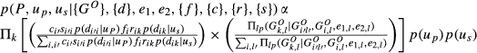

(1)

where *P* is the pedigree; *u*<sub>*p*</sub> and *u*<sub>*s*</sub> are the pollen and seed dispersal parameters; *G*<sup>*O*</sup> is the observed genotype of all individuals for locus *l*; *d* is the pairwise distance between individuals; *c* and *f* are the weight factors represented by the number of flowers (*i.e*. pollen production of paternal plant *i'*) and number of seeds (*i.e*. fecundity of maternal plant *i*), respectively; *r* is the plant-seedling temporal compatibility, indicating whether a seedling *k* recruited after mother *i* flowered (1 or 0); *s* is the flowering synchronization to assure that plants are able to mate by indicating whether flowering of plant *i'* and *i* occur in the same year (1 or 0); *e*<sub>1</sub> and *e*<sub>2</sub> are the mistyping and dropout errors of locus *l*; and *p*(*u*<sub>*p*</sub>) and *p*(*u*<sub>*s*</sub>) are the priors related to the dispersal parameters. Selfing was not allowed in the model, so the same plant cannot be simultaneously the mother and father of the same seedling.

Flower production (*c*) was measured as the total number of flowers each individual plant produced over the study period and is the product of the number of inflorescences and the average number of flowers per inflorescence. Fecundity (*f*) was calculated as the product of the maturation rate from flower to ripe fruits (from Uriarte *et al*. 2011) and the number of seeds per fruits. The maturation rates used for calculating the number of seeds (fecundity) were 0.15 for CF1, 0.08 for CF2 and 0.5 for F1, F2 and F3 (Uriarte *et al*. 2011, M.T.B. da Silva, unpublished data). Each fruit produces two seeds on average (1.9 ± 0.02 seeds/fruit, mean ± SE, *n* = 873 fruits, E. Bruna unpublished data).

where parameters are as in eqn 1 and separate *u*'s are estimated for pollen and seeds. We chose the 2D—t function, instead of other commonly used functional forms, because it allows for higher probabilities of both short- and long-distance dispersal, relative to a normal distribution (Clark *et al*. 1999; Moran & Clark 2012a). To compare pollination and seed dispersal distances, we used the mode, rather than the mean, to characterize the most frequent dispersal events (Clark *et al*. 1999).

Pedigree and other parameters in eqns 1 and 2 were estimated using a Gibbs sampler, using parentage probabilities and ecological data. In the resulting pedigree, each seedling is assigned to the pair of parents that presented the highest proportional allocation in the 50 000 simulations conducted within the model. Many times, plants within the plot are not ecologically and genetically likely to be a seedling's parent. In this case, the seedling is more likely assigned to a hypothetical plant (located outside the 1.26-ha sampled plot), which conveys the rate of immigration. It is possible that immigration rates were overestimated, because some reproductive plants died before they could be genotyped (Table 1). Model implementation follows the code proposed by Moran & Clark (2011). Implementation and information on the effects of different priors and density of hypothetical parents on posteriors are provided in the Data S2 (Supporting information).

Table 1. Characteristics of populations of *Heliconia acuminata* in the study site: total number of reproductive plants (number of dead plants not sampled in parentheses), percentage (%) and density of flowering plants, and number of sampled seedlings (the total number of seedlings recruited is indicated in parentheses)

| Population | Reserve number | Total No. of flowering plants (1999–2009) | % Total flowering (1999–2009; yearly range) | Total density of flowering plants (plants per m<sup>2</sup>) | Average of total plant density (1999–2009; yearly range) | No. of seedlings (1999–2009) |
| --- | --- | --- | --- | --- | --- | --- |
| CF1 | 1501 | 285 (3) | 15 (0.4–12.3) | 0.0226 | 732 (544–837) | 374 (681) |
| CF2 | None (Dimona) | 20 (5) | 5 (0–5.6) | 0.0016 | 122 (110–132) | 52 (80) |
| F1 | 3114 | 44 (2) | 7 (0–3.4) | 0.0035 | 227 (203–249) | 118 (172) |
| F2 | 2107 | 50 (0) | 9 (0–7.4) | 0.0040 | 221 (208–232) | 73 (112) |
| F3 | 2108 | 60 (3) | 16 (2.4–15.0) | 0.0047 | 185 (146–219) | 83 (127) |

### Reproductive dominance

Reproductive dominance was investigated using the pedigree recovered from the gene dispersal model and considering only the seedlings that had at least one parent identified within the 1.26-ha plot. Reproductive dominance is a measure of the genetic contribution of reproductive plants to the seedlings in the population, either via pollen or seeds. It was calculated using the probability of parental identity (PPaI) metric (Data S3, Supporting information). PPaI is analogous to the probability of paternal identity (Smouse & Robledo-Arnuncio 2005) and maternal identity (Grivet *et al*. 2005), and measures the probability that two offsprings randomly sampled from a population share the genotype of either a father or mother. PPaI was estimated using a variation of the unbiased *r*—estimator *R*<sub>0</sub> (Data S3, Supporting information), and ranges between 0 (seedlings do not share any parental genotype) and 1 (seedlings share genotypes of both parents). Confidence intervals were calculated by extracting PPaI values of 1000 bootstrapped samples of the actual sample.

### Genetic diversity, inbreeding and fine-scale spatial genetic structure

To evaluate if differences in gene dispersal metrics were reflected in the genetic make-up of the populations, we also analysed the genetic diversity, inbreeding coefficient and fine-scale spatial genetic structure. Genetic diversity of seedlings and reproductive plants of each population was characterized by the unbiased expected heterozygosity (UH<sub>e</sub>) and average number of alleles per locus (*N*<sub>a</sub>). These metrics were calculated using GenAlEx (Peakall & Smouse 2006). The inbreeding coefficient and fine-scale spatial genetic structure were characterized using the Loiselle kinship estimator (Loiselle *et al*. 1995) using SPAGEDi (Hardy & Vekemans 2002). The inbreeding coefficient (*F*<sub>is</sub>) was measured as the intra-individual kinship coefficient. Because *H. acuminata* is effectively nonselfing, the coefficient represents the effect of biparental inbreeding. The fine-scale spatial genetic structure was quantified by the *sp*-statistic, which measures the rate of decay of pairwise kinship with the logarithm of the distance between individuals. The s*p* –statistic is calculated as −*b*<sub>F</sub>/(1 − *F*<sub>1</sub>), where *b*<sub>F</sub> is the slope of the regression between pairwise kinship coefficients and distance, and *F*<sub>1</sub> is the average pairwise kinship coefficient between neighbours (defined here as individuals within 10 m radius for seedlings and 15 m for adults, chosen to optimize the proportion of participating individuals in the interval; Vekemans & Hardy 2004). Significance of the inbreeding coefficients was tested by permuting genes among all individuals 2000 times, whereas significance of *sp*-statistic was tested by permuting the spatial location of individuals 2000 times to obtain a frequency distribution of the regression slope (*b*<sub>F</sub>) under the null hypothesis that kinship is not correlated with distance. To evaluate whether plant density would influence the estimated parameters and to compare these values across populations, we estimated a confidence interval around the observed inbreeding and *sp*-statistic by running the analysis on 2000 bootstrapped samples of size equal the number of seedlings and adults in the least dense population.

## Results

### Propagule dispersal distances and immigration

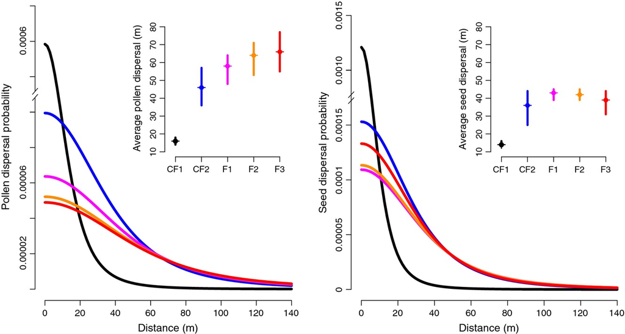

**Figure 1**

Open in figure viewer[PowerPoint](https://onlinelibrary.wiley.com/action/downloadFigures?id=mec12495-fig-0001&doi=10.1111%2Fmec.12495)

Realized dispersal of pollen and seeds. Main graph: Modelled kernel using the 2Dt-function, given the posterior mean of pollen dispersal (u<sub>p</sub>) and seed dispersal (u<sub>s</sub>) parameters. Scale of y-axis is different for pollen and seed dispersal, with seed dispersal reaching higher limits, by virtue of being more distance-restricted. The y-axis is broken to permit clear visualization of all kernels because probability of pollen and seed dispersal at short distances in CF1 was higher than in other populations. The x-axis was truncated at 140 m. Graph inset: average modal distance of pollen and seed dispersal and associated 95% support intervals obtained from 50 000 simulations for each population of *Heliconia acuminata*. Nonoverlapping intervals indicate that modal distances are significantly different.

Table 2. Total number and percentage of seedlings with parents located inside and outside the 1.26 ha plot, and number and percentage of reproductive plants that were assigned as either pollen (fathers) or seed donors (mothers)

[output not shown]

### Reproductive dominance

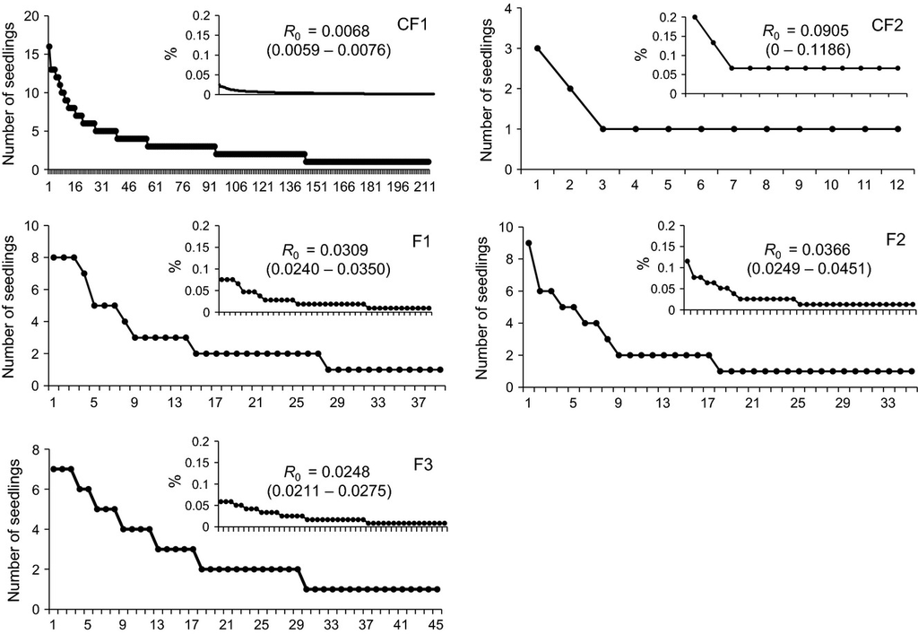

**Figure 2**

Open in figure viewer[PowerPoint](https://onlinelibrary.wiley.com/action/downloadFigures?id=mec12495-fig-0002&doi=10.1111%2Fmec.12495)

Number of seedlings each plant fathered or mothered (main graph); proportional genetic contribution of individual reproductive plants (graph inset) via either pollen or seeds to the next generations of seedlings and *R*<sub>0</sub> (PPaI—values) of *Heliconia acuminata* in each population. The *y*-axis represents the number of seedlings or proportional contribution (sum across reproductive plants is equal to one), and the *x*-axis represents each reproductive plant that contributed genes. The curve represents the decreasing ranking of the plants given their contribution. Flat curves indicate even contribution, whereas steep curves represent uneven genetic contribution.

### Genetic diversity, fine-scale spatial genetic structure and inbreeding

Expected heterozygosity and numbers of alleles were consistently similar across populations and between seedlings and reproductive adults, with a total heterozygosity average of 0.673 and 7.9 alleles per locus (Table 3). Fine-scale spatial genetic structure was significant but weak in all populations of seedlings (ranging from 0.0025 to 0.0142; Table 3). In fact, autocorrelograms of average pairwise kinship plotted for each distance interval showed that in most cases, kinship values are within the confidence interval envelopes and that only CF1, F2 and F3 presented significant positive kinship values at short distances (Fig. 3). For reproductive adults, only CF1 and F3 yielded significant *sp*-statistics (0.0041 and 0.0125, respectively; Table 3), with positive average kinship values in the first distance interval (<15 m; Fig. 3). *Sp*-values, however, did not vary significantly across populations, as indicated by the overlapping confidence intervals (Data S5, Fig. S5, Supporting information).

Table 3. Unbiased expected heterozygosity (UHe), mean number of alleles per locus (*N*<sub>a</sub>), inbreeding coefficient (*F*<sub>is</sub>) and fine-scale spatial genetic structure (*sp*-value) of reproductive plants and seedlings of *Heliconia acuminata*

|  | Seedlings UH<sub>e</sub> | Seedlings *N* <sub>a</sub> | Seedlings *F* <sub>is</sub> | Seedlings *P*-value | Seedlings *sp* | Seedlings *P*-value | Reproductive plants UH<sub>e</sub> | Reproductive plants *N* <sub>a</sub> | Reproductive plants *F* <sub>is</sub> | Reproductive plants *P*-value | Reproductive plants *sp* | Reproductive plants *P*-value |
| --- | --- | --- | --- | --- | --- | --- | --- | --- | --- | --- | --- | --- |
| CF1 | 0.624 | 9.2 | 0.038 | <0.001 | 0.0025 | <0.001 | 0.621 | 9.1 | 0.025 | 0.029 | 0.0041 | 0.000 |
| CF2 | 0.694 | 7.3 | 0.089 | <0.001 | 0.0142 | <0.001 | 0.693 | 7.0 | 0.131 | 0.001 | −0.0146 | 0.068 |
| F1 | 0.661 | 7.4 | 0.086 | <0.001 | 0.0051 | 0.006 | 0.687 | 6.7 | 0.085 | 0.002 | −0.0005 | 0.920 |
| F2 | 0.709 | 8.2 | 0.117 | <0.001 | 0.0122 | <0.001 | 0.700 | 8.0 | 0.102 | 0.000 | 0.0043 | 0.122 |
| F3 | 0.698 | 7.8 | 0.051 | 0.008 | 0.0131 | <0.001 | 0.701 | 8.2 | 0.062 | 0.010 | 0.0125 | 0.002 |

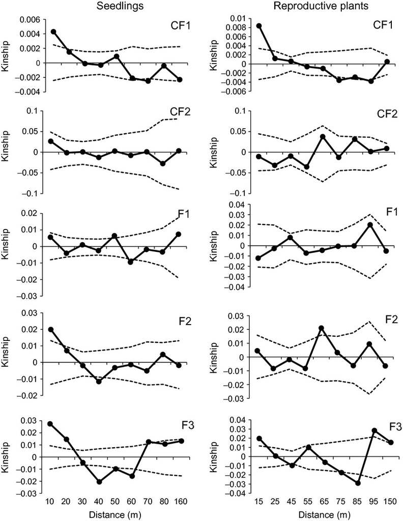

**Figure 3**

Open in figure viewer[PowerPoint](https://onlinelibrary.wiley.com/action/downloadFigures?id=mec12495-fig-0003&doi=10.1111%2Fmec.12495)

Autocorrelogram of pairwise kinship against distance (metres) of seedlings and reproductive plants across the five populations of *Heliconia acuminata* at the Biological Dynamics of Forest Fragments Project.

Inbreeding coefficients of seedlings and of adults were significantly different from random mating in all populations, with CF1 presenting low inbreeding coefficients of 0.038 and 0.025, compared to a range of 0.051–0.131 in the other populations (Table 3). Despite differences in the values of inbreeding and fine-scale spatial structure, the confidence intervals of bootstrapped samples overlapped, indicating that values are not significantly different among populations (Data S5, Fig. S5, Supporting information).

## Discussion

We examined gene dispersal across populations using a comprehensive approach that jointly exploits genetic and ecological data—including data on fecundity and phenology—while incorporating multiple sources of uncertainty and the contribution of outside parents via immigration of propagules. We found that populations with low density of reproductive plants presented higher realized propagule dispersal distances, immigration and reproductive dominance than did the high-density population. Therefore, our results corroborate the hypothesis that propagule dispersal is more strongly associated with the density of reproductive plants than with the potential effects of fragmentation on pollinators and seed dispersers. We found that genetic diversity, inbreeding and fine-scale spatial genetic structure were not significantly different across the landscape, which may indicate that populations can sustain similar levels of genetic patterns through distinct processes, with longer dispersal events in low-density populations and higher diversity of contributing parents in high-density populations.

### Fragmentation, plant density and gene dispersal

Counter to the prediction that forest fragmentation disrupts pollination and seed dispersal, we found gene dispersal to be enhanced in populations with low density of reproductive plants. This means that the detrimental effects of fragmentation on genetic processes are not applicable in all situations. For instance, the isolation of fragments may not always hinder animal and propagule movement (Kramer *et al*. 2008; Hadley & Betts 2011). In fact, the abundance of pollinators at BDFFP did not change after landscape fragmentation (Stouffer & Bierregaard 1995a), and frugivorous birds regularly visited small forest fragments, as the cleared matrix experienced secondary succession (Stouffer & Bierregaard 2007). High gene flow via pollen movement beyond boundaries of isolated forest fragments has been recorded elsewhere for animal-pollinated plants (Nason & Hamrick 1997; Aldrich & Hamrick 1998; White *et al*. 2002; Dick *et al*. 2003; Kamm *et al*. 2009; Lander *et al*. 2010). In contrast, gene flow via seed dispersal by animals beyond fragment boundaries has received scant attention, and results to date are inconsistent. For instance, Hanson *et al*. (2007) assigned 14 of 23 seed endocarps of *Dipteryx panamensis* to mothers outside fragments demonstrating that bat-mediated dispersal can connect isolated patches. Conversely, parentage analysis of *Araucaria angustifolia* in Brazil showed that seed immigration into forest fragment was absent, possibly the result of dispersal by gravity and limited dispersal by secondary dispersers (Bittencourt & Sebbenn 2007).

Propagule dispersal distances in *Heliconia acuminata* exhibited a stronger association with density of reproductive plants than with fragmentation per se. Average pollen and seed dispersal distances for the low-density continuous forest (CF2) were more similar to those of fragments than to that of the high-density continuous forest site (CF1). Both theoretical and empirical studies predict that pollinators will spend more time visiting flowers within the same plant or forage on the nearest neighbour when plant density is low, ultimately resulting in shorter pollination distances (see Ghazoul (2005) and references therein). Paternity analyses across fragmented landscapes, however, have found extensive gene flow in populations with reduced plant density (Stacy *et al*. 1996; Breed *et al*. 2012b; Llorens *et al*. 2012). As appears to be the case in our study, this is frequently found to be due to more localized foraging in dense patches. Our seed dispersal findings also corroborate results from a few seed dispersal studies showing that increasing plant aggregation and abundance of fleshy fruits decreases seed dispersal distances, as birds concentrate foraging in areas of higher fruit density (Morales & Carlo 2006; Herrera *et al*. 2011).

In sites with sparsely distributed reproductive plants, birds must travel farther and cover larger areas to meet their energetic requirements (Hadley & Betts 2011; Khamcha *et al*. 2012). This pattern is particularly marked for specialist pollinators (Ahmed *et al*. 2009) and frugivorous birds with narrow dietary preferences (Kwit *et al*. 2004). The abundance of hummingbirds in the study site is higher between January and April, the period when *H. acuminata* is flowering (Stouffer & Bierregaard 1996), suggesting that the birds are tracking critical nutritional resources over time. Experiments in captivity and laboratory analyses have also shown that the high lipid content of the fruits of *H. acuminata* makes them a preferred food resource for manakins (S. Hashimoto, unpublished data), suggesting that frugivorous birds may also track fruiting across the landscape.

### Immigration and reproductive dominance

Despite these differences in reproductive dominance among populations, the values of PPaI were generally low. This indicates that contributions of reproductive plants to seedling genotypes were relatively even, relative to other systems (e.g. Aldrich & Hamrick 1998; Sezen *et al*. 2005). The low reproductive dominance observed in our study may result from the large number of flowering plants (in CF1), flowering asynchrony and high seed-removal rates, relative to highly fecund tree species that have been the focus of previous studies.

### Genetic diversity, inbreeding and fine-scale spatial genetic structure

The significant inbreeding coefficient of seedlings and reproductive plants across populations indicates that mating between genetically related plants does occur in *H. acuminata*, which can help generate the significant fine-scale spatial genetic structure of seedlings in all populations. Although the fine-scale spatial genetic structure did not differ between reproductive plants and seedlings, most of the populations exhibited nonsignificant (or extremely low) *sp*-values for adult plants. It is possible that there is a trend towards the attenuation of spatial genetic structure with increasing life stage, which may occur due to demographic thinning and density-dependent mortality (Chung *et al*. 2003; Zhou & Chen 2010) or due to the spatial pattern of flowering (Hirao & Kudo 2008). Comparisons across populations, however, show that neither inbreeding levels nor spatial genetic structure is significantly different. Given the consistently similar genetic diversity of seedlings and reproductive plants across populations, it is possible that genetic diversity is maintained across this landscape by different processes: the immigration of propagules into fragments and low-density populations, and the high diversity of parental contribution in denser populations.

### Caveats

In our discussion, we have largely ignored myriad ecological and genetic processes that take place between pollen deposition on floral stigmas and seedling establishment. It is possible that postdispersal processes may restructure the spatial structure of seedlings. For instance, spatially structured mortality, due to Janzen–Connell effects, could reduce the number of offspring close to maternal plants (Isagi *et al*. 2007; Steinitz *et al*. 2011; Choo *et al*. 2012). If survival of plants is plot and microsite dependent, sampling seedlings could have exacerbated differences in dispersal distances among populations. In the study site, the proportion of dead seedlings did vary across populations (48% in CF1, 33% in CF2, 51% in F1, 39% in F2 and 36% in F3 of all seedlings recruited between 1999 and 2008 were dead in 2009, χ<sup>2</sup> = 12.68, d.f. = 4, *P* = 0.0129, *N* = 1046). Fine-scale spatial genetic structure, however, did not vary much between cohorts or among populations, suggesting that plant mortality at later stages is unlikely to be spatially structured.

Moreover, the BDFFP landscape is surrounded by large expanses of primary forest with fragment boundaries distant only 100 m from continuous forests. Given more substantial habitat isolation, manakins and thrushes might not move to other forested patches. If trapped within a fragment, these birds might eventually disappear from the system, leading to the genetic erosion that we do not see here. Nevertheless, our study shows that the secondary growth on cleared land does not impede the movement of both seed dispersers and pollinators across this landscape. A considerable portion of global tropical forest cover consists of forest regrowth, following logging, agricultural abandonment or conversion to agroforests (FAO 2011), making our findings relevant to tropical forests elsewhere.

## Conclusions

Our results show that gene dispersal across a heterogeneous, historically fragmented landscape, is more related to density of flower and fruit resources than to fragmentation per se. Forest fragmentation, however, can further enhance gene dispersal by reducing the abundance of plants within patches (Bruna 1999, 2002; Uriarte *et al*. 2010), enforcing movement among forested areas. Our study shows that continuous forest sites can have striking variation in plant abundance, which translates into divergent propagule dispersal outcomes.

Plant population dynamics and persistence in fragmented landscapes can be assessed using methods that allow contemporary and spatially explicit evaluation of ongoing genetic processes. We suggest that future studies of contemporary gene flow should take into consideration plant and dispersal vector features, which vary across changing landscapes. Reformulating a new set of predictions within conservation genetics will require the contribution of additional studies to draw a more representative picture of how interactions between landscape configuration and organismal traits influence the processes of pollination and seed dispersal.

## Acknowledgements

We thank Dustin Rubenstein and three anonymous reviewers for valuable comments on the manuscript. We would like to thank Jeffrey Hunt, Gabriel Johnson, Ida Lopez and David Erickson for assistance in the development of the molecular markers and Lee Weigt for facilitating our work in the Museum Support Center, Smithsonian Institution. We are grateful for the help provided by Carla Sardelli and Carolina Medeiros at LabGen, INPA and Osmaildo Ferreira da Silva for assistance in the field. We thank Emily Moran for sharing the code and helping with the model interpretation and Lora Murphy for help in adapting the code to our system. We also thank BDFFP and INPA for their logistical support. Financial support was provided by the US National Science Foundation (award DEB-0614339 to MU, DEB-0614149, DEB-0309819, DBI-0109226 and INT 98-06351 to EB) and the Smithsonian Institution. MRL and RG acknowledge research fellowships from CNPq/Brazil. This is publication number 626 in the BDFFP Technical Series.

## References

M.C.C., W.J.K. and E.B. collected the data in the field; M.C.C. performed the research and wrote the paper; M.C.C., M.U. and P.S. contributed to the statistical analyses; W.J.K., M.R.L. and R.G. contributed reagents and laboratory material; all authors contributed to writing the paper.

## Data accessibility

Original code of the gene dispersal model can be found on Emily Moran's website: https://sites.google.com/site/emilyvmoran/.

Sample locations, microsatellite data and modified code deposited in the Dryad repository: doi: 10.5061/dryad.b003f.

## Citing Literature

[figure not shown]

[Volume22, Issue22](https://onlinelibrary.wiley.com/toc/1365294x/2013/22/22)

November 2013

Pages 5716-5729

### Recommended

  [Biological Reviews](https://onlinelibrary.wiley.com/journal/1469185x)

[Download PDF](https://onlinelibrary.wiley.com/doi/pdf/10.1111/mec.12495)

[back](https://onlinelibrary.wiley.com/doi/10.1111/mec.12495)